# Survival Analysis

03/19/2018

## Binary Covariate - Survival Time Outcome

## Binary Covariate - Survival Time Outcome

- For this problem we are looking at a survival time outcome.
- This type of outcome has both event status as well as a time included.
- For this type we might be comparing how long after taking a medication that a patient is cured.
- We will look at various ways to do this now.

## Goals of Survival Analysis

- Goals of Survival Analysis:
  - Estimate distribution of of survival time for a population
  - Test for equality of survival distributions among 2 or more groups
    - Control
    - Treated
  - Estimate the absolute or relative treatment effects
  - Estimate and control for effects of other covariates
    - Confounding
    - Effect Modification/Interaction
  - Find confidence intervals and significance for effects.

## Describing and Characterizing Survival Data

- The event
  - What is the event of interest?
  - How is it specifically defined?
- The Origin
  - What is the initial starting point?
  - This must be before anyone in the study has had the event of interest.
- The Metric for time
  - What is the scale in which events are recorded.

## Examples

- Time to relapse after end of treatment among cancer patients.
  - *Event*: Relapse of Cancer
  - *Origin*: End of Treatment.
  - *Time Metric*: Days
- Length of stay in hospital for patients who suffered a heart attack.
  - *Event*: Leaving Hospital.
  - *Origin*: Admission to Hospital.
  - *Time Metric*: Hours.

## Examples

- Age of onset of breast cancer in individuals with family history.
  - *Event*: Onset of Breast Cancer.
  - *Origin*: Birth.
  - *Time Metric*: Years

## The Survival Function

- The random variable of interest, \(T\) is the time to the event of interest.
- We then know that \(T\) is positive and by definition: \[T\ge0\] The Survival function, \(S(t)\), is the proportion of individuals who have not experienced at event at some time \(t>0\).This is defined by: \[S(t) = \Pr(T>t)\]

## The Survival Function

- If the event of interest is death, this would mean the subject is still alive at time \(t\).
- Then \(S(t)\) would be the proportion of subjects alive at time \(t\).
- This simple proportion is for when there is no *censoring* (discussed later on).

## Features of \(S(t)\)

- A survivor function is a sequence of probabilities up till time \(t\) \[0\le S(t)\le1, \qquad \text{ for each } t\ge0\]
- At time, \(t=0\), \(S(0)=1\).
- \(S(t)\) decreases as events happen over \(t\)
  - So that if \(t_2\ge t_1\) then \(S(t_2)\le S(t_1)\).
  - They are non-increasing functions.

## Features of \(S(t)\)

- For large, \(t\), such as \(t=\infty\), \(S(t)\) goes to 0.
  - This means that for some events \(S(t)\) approaches a 0 asymptote.
  - However for some diseases, some people may be cured so that \(S(t)\) approaches a non-zero asymptote.
- Graphical displays are a common method to display summaries survivor functions.

## The Hazard Function

The Hazard function is defined as the instantaneous rate of failure at time \(t\), given that a subject as survived up until time \(t\).

It is also referred to as:

- Hazard Rate.
- Failure Rate.
- Mortality Rate

## Relationship between \(h(t)\) and \(S(t)\):

- The hazard function \((h(t))\), survival function \((S(t))\), probability density function \((f(t))\), and cumulative distribution function \((F(t))\) are all related.
- They are defined in terms of random variable \(T\) which is the time until event.
- In censored subjects we only know that \(T>t\) for a subject censored at time \(t\).
- Mathematically: \[h(t) = \dfrac{f(t)}{S(t)} = -\dfrac{\dfrac{d}{dt}S(t))}{S(t)} = -\dfrac{d}{dt}\log\left[S(t)\right]\]

## Kaplan-Meier Estimator

- Kaplan-Meier is a non-parametric method.
  - No assumptions of distribution
- We define patients to be at risk at time \(t\) if they have not experienced the event just before time \(t\) and are not yet censored just before time \(t\).

## Log Rank Test

- The Logrank Test is a hypothesis test for 2 or more independent samples of survival data.
- The hypothesis being tested are:

\[H_0: S_1(t) = S_2(t) \text{ for all }t\] \[\text{and}\] \[H_1: S_1(t) \ne S_2(t) \text{ for some }t\]

## Log Rank Test

If \(H_0\) is true then

- \(h_1(t)=h_2(t) \text{ for all }t\)
- \(\Lambda_1(t)=\Lambda_2(t) \text{ for all }t\)

## How do we calculate this test statistic?

1. Construct a 2x2 table at the time of each observed failure.
2. Calculate the Mantel-Haenszel chi-square test statistic.
- We have \(K\) distinct observed failure times: \[t_1<\cdots<t_K\]
- at the \(i^{\text{th}}\) observed failure time \(t_i\):

## How do we calculate this test statistic?

| Treatment | Died | Alive | At Risk |
| --- | --- | --- | --- |
| Control | \(a_i\) | \(b_i\) | \(n_{1i}\) |
| Treated | \(c_i\) | \(d_i\) | \(n_{2i}\) |
| total | \(m_{1i}\) | \(m_{2i}\) | \(n_i\) |

where \[\begin{aligned} n_{1i} &= \text{ number at risk at } t_i \text{ from Control}\\ n_{2i} &= \text{ number at risk at } t_i \text{ from Treated}\\ m_{1i} &= \text{ number of failures at } t_i\\ m_{2i} &= \text{ number surviving past } t_i\\ n_i &= \text{ total numer at risk at } t_i\\ \end{aligned}\]

## Relation to Mantel-Haenszel Test

- This test is exactly the same as a Mantel-Haenszel test applied to \(K\) strata \[\chi^2_{MH} = \dfrac{\left[\sum_{i=1}^K (a_i - E(a_i))\right]^2}{\sum_{i=1}^K Var(a_i)}\]
- where \[\begin{aligned} E(a_i) &= \dfrac{n_{1i}m_{1i}}{n_i}\\ Var(a_i) &= \dfrac{n_{1i}n_{2i}m_{1i}m_{2i}}{n_i^2(n_i-1)}\\ \end{aligned}\]

## Relation to Mantel-Haenszel Test

We compute the expectation that the null hypothesis is true and there is no difference in survival between the groups. We consider all margins fixed but \(a_i\) is random and thus we have a hypergeometric distribution.

- Under \(H_0\) we have that \(S_1(t)=S_2(t)\) and this means
  - \(\chi^2_{MH}\sim \chi^2_1\)
  - Reject \(H_0\) when \(\chi^2_{MH}>\chi^2_{1,1-\alpha}\)
- This test is most powerful if the hazard ratio is constant over time.
- We can easily extend this to compare 3 or more independent groups.

## Recall the Colorectal Cancer component of the Physicians Health Study

| Name | Description |
| --- | --- |
| age | Age in years at time of Randomization |
| asa | 0 - placebo, 1 - aspirin |
| bmi | Body Mass Index (kg/\(m^2\)) |
| hypert | 1 - Hypertensive at baseline, 0 - Not |
| alcohol | 0 - less than monthly, 1 - monthly to less than daily, 2 - daily consumption |

| Name | Description |
| --- | --- |
| dm | 0 = No diabetes Mellitus, 1 - diabetes Mellitus |
| sbp | Systolic BP (mmHg) |
| exer | 0 - No regular, 1 - Sweat at least once per week |
| csmoke | 0 - Not currently, 1 - < 1 pack per day, 2 - \(\ge\) 1 pack per day |
| psmoke | 0 - never smoked, 1 - former < 1 pack per day, 2 - former \(\ge\) 1 pack per day |
| pkyrs | Total lifetime packs of cigarettes smoked |
| crc | 0 - No colorectal Cancer, 1 - Colorectal cancer |
| cayrs | Years to colorectal cancer, or death, or end of follow-up. |

## What Each Subject Contributed

1. Information on whether of not they had a Colorectal Cancer(CRC) during follow-up
2. Follow-up time in years, specified as time from randomization until first of
   - end of Study
   - death
   - Colorectal Cancer
   - Loss to follow-up

## Loading Data

```r
library(tidyverse)
library(haven)
phscrc <- read_dta("phscrc.dta")
phscrc <- phscrc %>% mutate(age.cat = cut(age, c(40, 50, 60,
    70, 90), right = FALSE)) %>% mutate(alcohol.use = factor(alcohol >
    1, labels = c("no", "yes"))) %>% mutate(obese = factor(bmi >
    30, labels = c("Not Obese", "Obese")))
```

## Example: Kaplan-Meier Survival

```r
library(survival)

model <- survfit(Surv(cayrs, crc) ~ alcohol.use, data = subset(phscrc,
    cayrs > 0))
model
```

## Example: Kaplan-Meier Survival

```
## Call: survfit(formula = Surv(cayrs, crc) ~ alcohol.use, data = subset(phscrc,
##     cayrs > 0))
##
##                     n events median 0.95LCL 0.95UCL
## alcohol.use=no  12162    173     NA      NA      NA
## alcohol.use=yes  3856     81     NA      NA      NA
```

## Plotting the Kaplan-Meier

```r
library(survminer)
ggsurvplot(model, conf.int = FALSE, risk.table = TRUE, risk.table.col = "strata",
    legend.labs = c("Non-Drinker", "Drinker"), break.time.by = 2,
    ylim = c(0.95, 1))
```

## Plotting the Kaplan-Meier

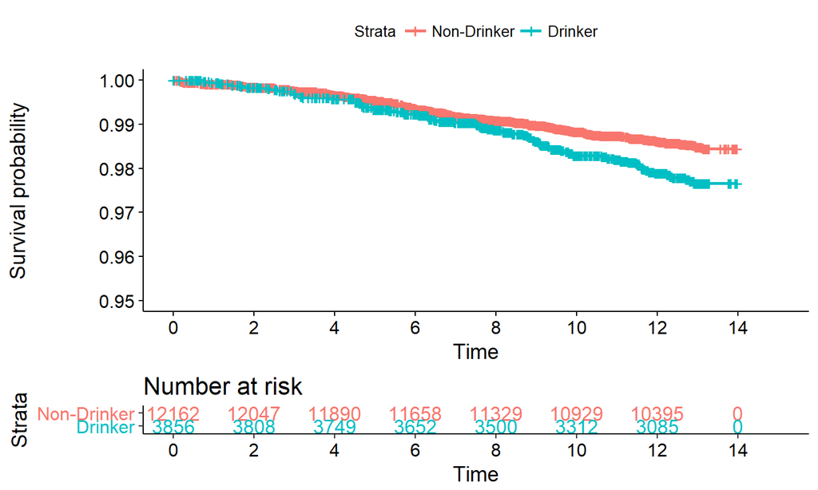

## Log Rank Test

```r
model <- survdiff(Surv(cayrs, crc) ~ alcohol.use, data = subset(phscrc,
    cayrs > 0))
model
```

## Log Rank Test

```
## Call:
## survdiff(formula = Surv(cayrs, crc) ~ alcohol.use, data = subset(phscrc,
##     cayrs > 0))
##
##                     N Observed Expected (O-E)^2/E (O-E)^2/V
## alcohol.use=no  12162      173      194      2.27      9.61
## alcohol.use=yes  3856       81       60      7.34      9.61
##
##  Chisq= 9.6  on 1 degrees of freedom, p= 0.00193
```

## Conclusion

- What can we conclude?

## Categorical Covariate - Survival Time Outcome

## Categorical Covariate - Survival Time Outcome

- Same exact method Kaplan-Meier and Log Rank.
- We will see an example of this.

## CRC Example: Kaplan-Meier Survival

```r
model <- survfit(Surv(cayrs, crc) ~ csmok, data = subset(phscrc,
    cayrs > 0))
model
```

```
## Call: survfit(formula = Surv(cayrs, crc) ~ csmok, data = subset(phscrc,
##     cayrs > 0))
##
##             n events median 0.95LCL 0.95UCL
## csmok=0 14307    217     NA      NA      NA
## csmok=1   575      7     NA      NA      NA
## csmok=2  1136     30     NA      NA      NA
```

```r
ggsurvplot(model, conf.int = TRUE, risk.table = TRUE, risk.table.col = "strata",
    break.time.by = 2, ylim = c(0.95, 1))
```

[output not shown]

## Log Rank Test

```r
model <- survdiff(Surv(cayrs, crc) ~ csmok, data = subset(phscrc,
    cayrs > 0))
model
```

## Log Rank Test

```
## Call:
## survdiff(formula = Surv(cayrs, crc) ~ csmok, data = subset(phscrc,
##     cayrs > 0))
##
##             N Observed Expected (O-E)^2/E (O-E)^2/V
## csmok=0 14307      217   227.41     0.476     4.549
## csmok=1   575        7     9.11     0.489     0.508
## csmok=2  1136       30    17.48     8.965     9.628
##
##  Chisq= 9.9  on 2 degrees of freedom, p= 0.00697
```